# Forecasting Western Australian specialised food retailing turnover

ETC3550 Applied forecasting (Monash University) retail project

Author

Tristan Labagala

```r
library(fpp3)
# ABS series A3349508C: Western Australia, other specialised food retailing
retail <- readr::read_rds("https://bit.ly/monashretaildata") |>
  filter(`Series ID` == "A3349508C")
```

```r
# Labels reused on every plot so units are always shown
y_lab <- "Turnover ($Million AUD)"
series_name <- "WA other specialised food retailing"
```

# Introduction

This report forecasts monthly retail turnover for **Other specialised food retailing** in **Western Australia** (ABS Series ID **A3349508C**). The data run from 1982 Apr to 2022 Dec (489 months) and are measured in millions of Australian dollars, in current prices and not seasonally adjusted. This ABS industry subgroup covers food retailers other than supermarkets and liquor stores: butchers, fresh fish shops, fruit and vegetable grocers, bakeries, and confectionery and specialty food stores.

The report first explores the series (Sections 1-2), chooses a transformation and decomposes the series (Sections 3-4), and checks stationarity (Section 5). It then short-lists, fits and compares ARIMA and ETS models using the last 24 months as a test set (Sections 6-8), produces a two-year forecast (Section 9), and checks that forecast against the latest ABS data (Section 10).

# 1. Plots of the series

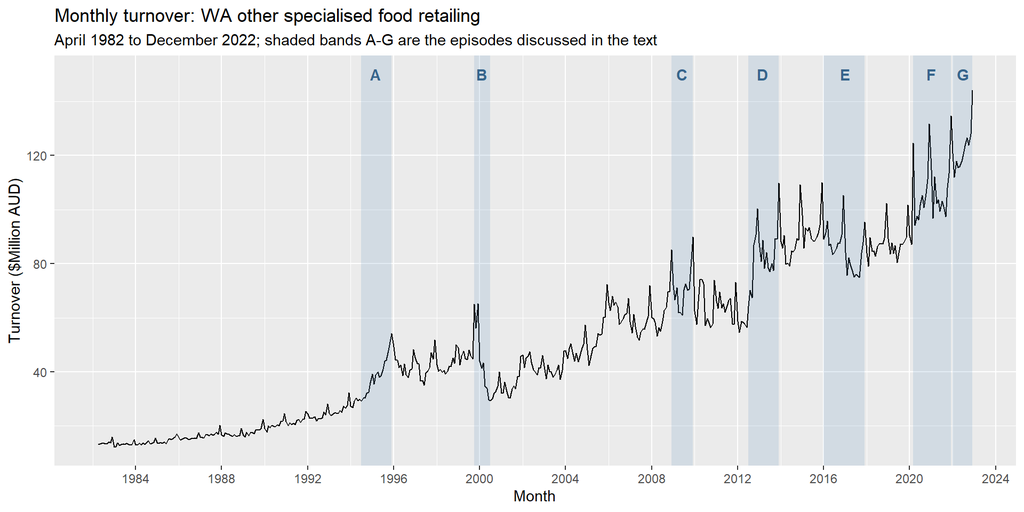

Figure 1

```r
# Key episodes, used to tie the explanations to dates on the plot
events <- tibble(
  label = c("A", "B", "C", "D", "E", "F", "G"),
  start = yearmonth(c("1994 Jul", "1999 Oct", "2008 Dec", "2012 Jul", "2016 Jan", "2020 Mar", "2022 Jan")),
  end   = yearmonth(c("1995 Dec", "2000 Jul", "2009 Dec", "2013 Dec", "2017 Dec", "2021 Dec", "2022 Dec"))
)

retail |>
  autoplot(Turnover) +
  annotate("rect",
    xmin = events$start, xmax = events$end, ymin = -Inf, ymax = Inf,
    fill = "steelblue", alpha = 0.15
  ) +
  annotate("text",
    x = events$start + round(as.numeric(events$end - events$start) / 2), y = 150,
    label = events$label, fontface = "bold", colour = "steelblue4"
  ) +
  scale_x_yearmonth(date_breaks = "4 years", date_labels = "%Y") +
  labs(
    title = paste("Monthly turnover:", series_name),
    subtitle = "April 1982 to December 2022; shaded bands A-G are the episodes discussed in the text",
    x = "Month",
    y = y_lab
  )
```

Turnover grew about 9-fold between 1983 and 2022, partly from inflation (the series is in current dollars) and partly from WA’s population growth. The growth came in steps that line up with WA events:

- **A (1994-95):** a jump of about 40% in one year, too large for spending alone, so probably partly an ABS reclassification.
- **B (1999-2000):** a Y2K stockpiling spike, then a lasting fall of about a third around the July 2000 GST, probably partly a measurement break.
- **C (2008-09):** no GFC slump, as stimulus payments and mining income lifted Christmas spending.
- **D (2012-13):** a jump at the peak of the mining boom; **E (2016-17):** a fall in WA’s post-boom recession.
- **F (2020-21):** COVID-19 (Section 2); **G (2022):** food price inflation.

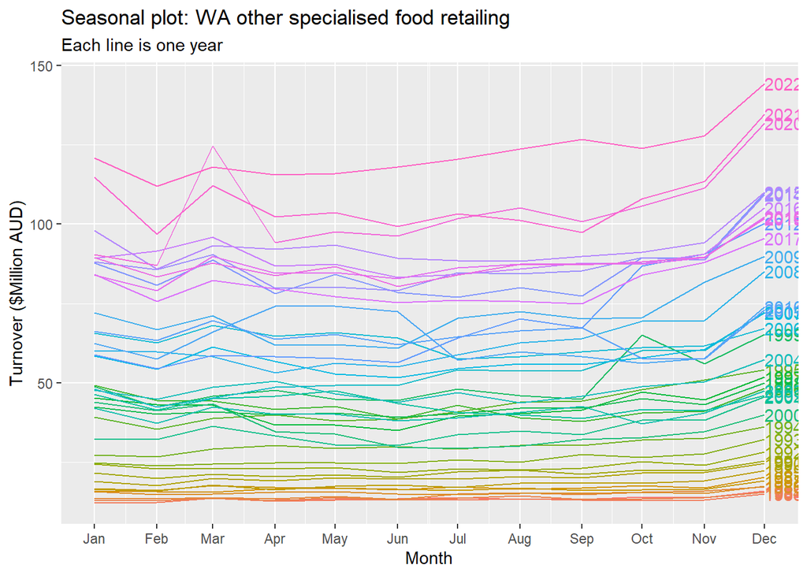

Figure 2

```r
retail |>
  gg_season(Turnover, labels = "right") +
  labs(
    title = paste("Seasonal plot:", series_name),
    subtitle = "Each line is one year",
    x = "Month",
    y = y_lab,
    colour = "Year"
  )
```

Every year dips in February and June and peaks in December with Christmas food shopping. Recent years are much further apart in December, so the peak grows with the level. Only 1999 (October, Y2K) and 2020 (March, panic buying) break the pattern.

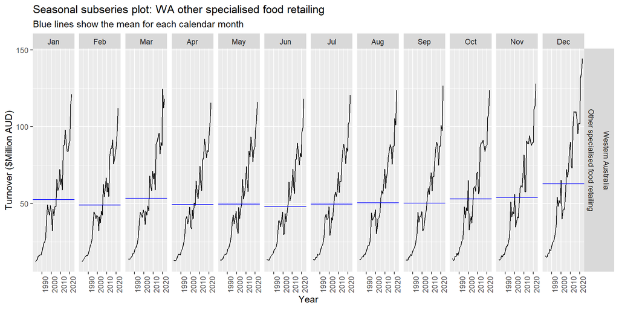

Figure 3

```r
retail |>
  gg_subseries(Turnover) +
  labs(
    title = paste("Seasonal subseries plot:", series_name),
    subtitle = "Blue lines show the mean for each calendar month",
    x = "Year",
    y = y_lab
  )
```

Every month follows the same long-run path, so the episodes above are shifts in the level of the series rather than seasonal events. December has by far the highest mean, so the seasonality is mostly a single Christmas peak.

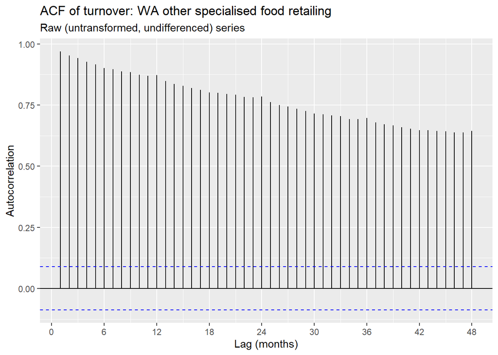

Figure 4

```r
retail |>
  ACF(Turnover, lag_max = 48) |>
  autoplot() +
  labs(
    title = paste("ACF of turnover:", series_name),
    subtitle = "Raw (untransformed, undifferenced) series",
    x = "Lag (months)",
    y = "Autocorrelation"
  )
```

The autocorrelations start at 0.97 and are still 0.64 at lag 48, the mark of a strong trend that hides the seasonality. The series is clearly non-stationary, so it is differenced in Section 5.

# 2. Statistical features, including COVID-19

```r
stl_feat <- retail |>
  features(Turnover, feat_stl) |>
  select(trend_strength, seasonal_strength_year)
stl_feat |>
  knitr::kable(digits = 2, col.names = c("Trend strength", "Seasonal strength"))
```

| Trend strength | Seasonal strength |
| --- | --- |
| 0.99 | 0.66 |

Trend strength is 0.99, so almost all long-run movement is trend. Seasonal strength is only 0.66: the December peak is regular, but the irregular jumps are large, so the models will have to cope with a lot of noise.

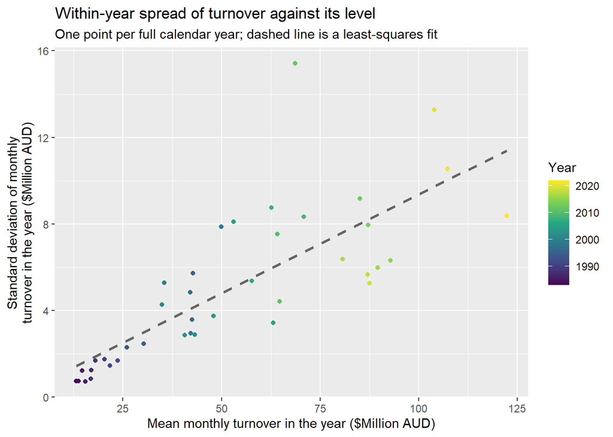

Figure 5

```r
level_spread <- retail |>
  as_tibble() |>
  group_by(Year = year(Month)) |>
  filter(n() == 12) |>
  summarise(Mean = mean(Turnover), SD = sd(Turnover))

level_spread |>
  ggplot(aes(x = Mean, y = SD)) +
  geom_point(aes(colour = Year)) +
  geom_smooth(method = "lm", formula = y ~ x, se = FALSE, colour = "grey40", linetype = "dashed") +
  scale_colour_viridis_c() +
  labs(
    title = "Within-year spread of turnover against its level",
    subtitle = "One point per full calendar year; dashed line is a least-squares fit",
    x = "Mean monthly turnover in the year ($Million AUD)",
    y = "Standard deviation of monthly\nturnover in the year ($Million AUD)",
    colour = "Year"
  )
```

Busier years vary more (correlation 0.78), and December’s lead over other months grew from $2.8M in the 1980s to $22M in 2013-2022. The variation is a roughly fixed percentage of the level, so a transformation is needed (Section 3).

**Unusual months.** I removed the trend and seasonality from log turnover with a robust STL decomposition and flagged months whose remainder lies more than 3 interquartile ranges below the first quartile or above the third quartile of the remainders:

```r
outlier_reasons <- tribble(
  ~Month, ~Reason,
  "1999 Oct", "Y2K stockpiling",
  "1999 Nov", "Y2K stockpiling",
  "1999 Dec", "Y2K stockpiling and millennium celebrations",
  "2000 Jul", "First month of the GST",
  "2002 May", "No clear cause; likely sampling noise",
  "2005 Mar", "Labour Day and Easter in the same month cut trading days",
  "2009 Nov", "No clear cause; possibly late spending from the 2009 stimulus",
  "2010 Apr", "Temporary Apr-Jun 2010 jump; possibly an ABS sample change",
  "2010 May", "Temporary Apr-Jun 2010 jump; possibly an ABS sample change",
  "2010 Jun", "Temporary Apr-Jun 2010 jump; possibly an ABS sample change",
  "2020 Mar", "COVID-19 panic buying"
) |>
  mutate(Month = yearmonth(Month))

outliers <- retail |>
  model(STL(log(Turnover) ~ season(window = 13), robust = TRUE)) |>
  components() |>
  as_tibble() |>
  filter(
    remainder < quantile(remainder, 0.25) - 3 * IQR(remainder) |
      remainder > quantile(remainder, 0.75) + 3 * IQR(remainder)
  ) |>
  left_join(retail |> as_tibble() |> select(Month, Turnover), by = "Month") |>
  left_join(outlier_reasons, by = "Month") |>
  select(Month, Turnover, remainder, Reason)

outliers |>
  mutate(Month = format(Month)) |>
  knitr::kable(
    digits = c(0, 1, 3, 0),
    col.names = c("Month", "Turnover ($Million AUD)", "STL remainder (log scale)", "Likely reason")
  )
```

| Month | Turnover ($Million AUD) | STL remainder (log scale) | Likely reason |
| --- | --- | --- | --- |
| 1999 Oct | 65.1 | 0.379 | Y2K stockpiling |
| 1999 Nov | 56.1 | 0.253 | Y2K stockpiling |
| 1999 Dec | 65.3 | 0.274 | Y2K stockpiling and millennium celebrations |
| 2000 Jul | 29.3 | -0.183 | First month of the GST |
| 2002 May | 47.5 | 0.216 | No clear cause; likely sampling noise |
| 2005 Mar | 45.2 | -0.195 | Labour Day and Easter in the same month cut trading days |
| 2009 Nov | 81.7 | 0.199 | No clear cause; possibly late spending from the 2009 stimulus |
| 2010 Apr | 74.2 | 0.256 | Temporary Apr-Jun 2010 jump; possibly an ABS sample change |
| 2010 May | 74.1 | 0.257 | Temporary Apr-Jun 2010 jump; possibly an ABS sample change |
| 2010 Jun | 72.5 | 0.275 | Temporary Apr-Jun 2010 jump; possibly an ABS sample change |
| 2020 Mar | 124.6 | 0.235 | COVID-19 panic buying |

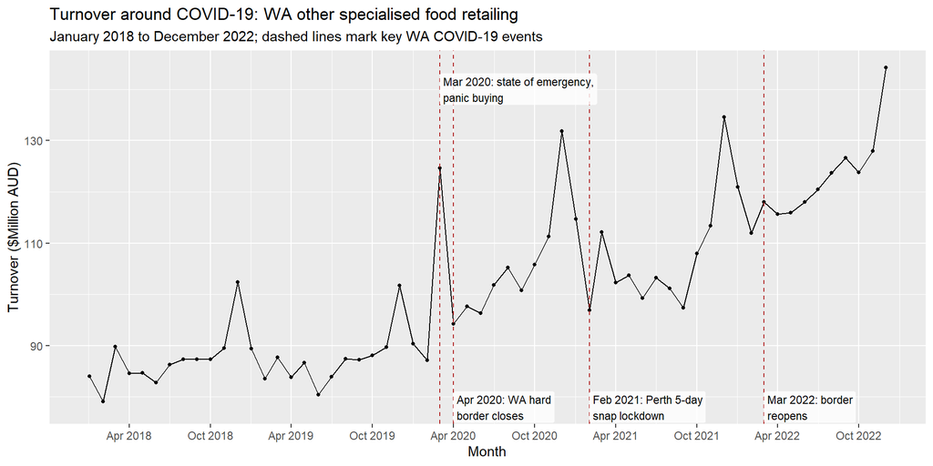

Figure 6

```r
covid_events <- tibble(
  Month = yearmonth(c("2020 Mar", "2020 Apr", "2021 Feb", "2022 Mar")),
  label = c(
    "Mar 2020: state of emergency,\npanic buying",
    "Apr 2020: WA hard\nborder closes",
    "Feb 2021: Perth 5-day\nsnap lockdown",
    "Mar 2022: border\nreopens"
  ),
  y = c(140, 78, 78, 78)
)

retail |>
  filter(year(Month) >= 2018) |>
  autoplot(Turnover) +
  geom_point(size = 1) +
  geom_vline(xintercept = covid_events$Month, linetype = "dashed", colour = "firebrick") +
  geom_label(
    data = covid_events, aes(x = Month, y = y, label = label),
    size = 3, hjust = 0, linewidth = 0, alpha = 0.8
  ) +
  scale_x_yearmonth(date_breaks = "6 months", date_labels = "%b %Y") +
  labs(
    title = paste("Turnover around COVID-19:", series_name),
    subtitle = "January 2018 to December 2022; dashed lines mark key WA COVID-19 events",
    x = "Month",
    y = y_lab
  )
```

**COVID-19.** Turnover jumped 43% in March 2020 as households stockpiled, then settled at a higher level: 2020 averaged 19% above 2019, as cafes closed, the hard border kept spending at home and income support lifted incomes. WA’s snap lockdowns lasted only days, so they barely show. For forecasting, the training set ends in December 2020, right after this jump, so the models start from an unusually high level.

# 3. Box-Cox transformation

```r
lambda_guerrero <- retail |>
  features(Turnover, features = guerrero) |>
  pull(lambda_guerrero)
```

The variation grows with the level (Section 2), but the models assume it does not, so a Box-Cox transformation is needed to even it out. Guerrero’s method suggests $\lambda =$ -0.29, but it is pulled around by the level shifts and unusual months, so I treated it as a starting point and compared it with 0 (log), 0.25, 0.5 and 1 (no change).

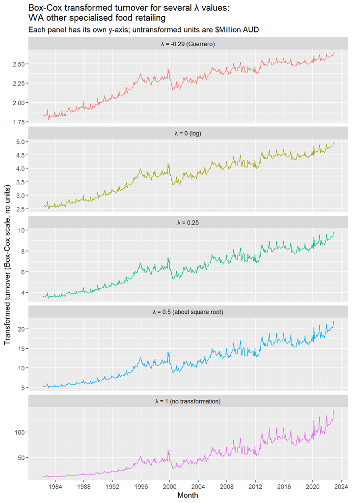

Figure 7

```r
lambda_grid <- tibble(
  lambda = c(lambda_guerrero, 0, 0.25, 0.5, 1),
  name = c(
    paste0("λ = ", round(lambda_guerrero, 2), " (Guerrero)"),
    "λ = 0 (log)", "λ = 0.25", "λ = 0.5 (about square root)", "λ = 1 (no transformation)"
  )
)

lambda_long <- lambda_grid |>
  mutate(data = purrr::map(lambda, \(l) retail |> mutate(Transformed = box_cox(Turnover, l)))) |>
  tidyr::unnest(data) |>
  mutate(name = factor(name, levels = lambda_grid$name)) |>
  as_tsibble(index = Month, key = name)

lambda_long |>
  autoplot(Transformed) +
  facet_wrap(vars(name), ncol = 1, scales = "free_y") +
  scale_x_yearmonth(date_breaks = "4 years", date_labels = "%Y") +
  theme(legend.position = "none") +
  labs(
    title = paste0("Box-Cox transformed turnover for several λ values:\n", series_name),
    subtitle = "Each panel has its own y-axis; untransformed units are $Million AUD",
    x = "Month",
    y = "Transformed turnover (Box-Cox scale, no units)"
  )
```

```r
# Size of the December peak in 2013-2022 relative to 1983-1989 (1 = same size)
lambda_check <- lambda_grid |>
  mutate(ratio = purrr::map_dbl(lambda, \(l) {
    yearly <- retail |>
      as_tibble() |>
      mutate(w = box_cox(Turnover, l)) |>
      group_by(Year = year(Month)) |>
      filter(n() == 12) |>
      summarise(dec_gap = w[month(Month) == 12] - mean(w[month(Month) != 12]))
    mean(yearly$dec_gap[yearly$Year >= 2013]) / mean(yearly$dec_gap[yearly$Year <= 1989])
  }))

lambda_check |>
  select(name, ratio) |>
  knitr::kable(digits = 2, col.names = c("λ", "December peak size: 2013-2022 / 1983-1989"))
```

| λ | December peak size: 2013-2022 / 1983-1989 |
| --- | --- |
| λ = -0.29 (Guerrero) | 0.76 |
| λ = 0 (log) | 1.28 |
| λ = 0.25 | 2.01 |
| λ = 0.5 (about square root) | 3.15 |
| λ = 1 (no transformation) | 7.76 |

```r
ratio_of <- \(l) lambda_check$ratio[which.min(abs(lambda_check$lambda - l))]
```

The table checks the plots by comparing the size of the December peak late and early in the series (1 = same size). With $\lambda$ = 1, 0.5 and 0.25 the recent peaks are still 7.8, 3.1 and 2 times the early ones, so the variation still grows. The log (1.28) and Guerrero’s value (0.76) both even it out, missing by similar amounts in opposite directions, and their panels look almost identical.

```r
lambda <- 0
```

**I chose the log ($\lambda = 0$).** It works as well as Guerrero’s value without relying on an estimate distorted by unusual months, and it makes the results easy to read as percentages (for example, “December is 20% above trend”). Forecasts are back-transformed to $Million AUD automatically and are always positive.

# 4. STL decomposition of the transformed data

STL splits log turnover into trend, seasonal and remainder parts. I compared window sizes rather than accepting the defaults, and used robust fitting so the one-off spikes from Section 2 stay in the remainder.

```r
fit_stl <- function(trend_window, season_window) {
  retail |>
    model(STL(
      box_cox(Turnover, lambda) ~ trend(window = trend_window) + season(window = season_window),
      robust = TRUE
    )) |>
    components()
}
```

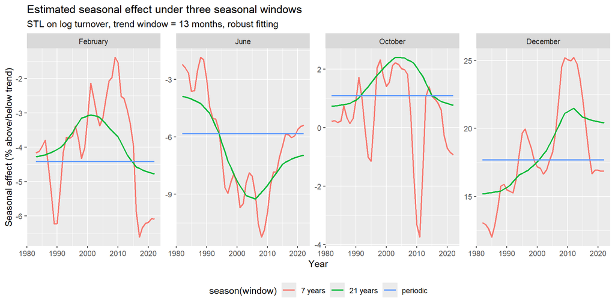

Figure 8

```r
season_windows <- list("7 years" = 7, "21 years" = 21, "periodic" = "periodic")

season_cmp <- purrr::imap(season_windows, \(sw, nm) fit_stl(13, sw) |> mutate(window = nm))

season_cmp |>
  purrr::map(as_tibble) |>
  bind_rows() |>
  filter(month(Month) %in% c(2, 6, 10, 12)) |>
  mutate(
    month = factor(month(Month, label = TRUE, abbr = FALSE), levels = month.name),
    window = factor(window, levels = names(season_windows)),
    effect = 100 * (exp(season_year) - 1)
  ) |>
  ggplot(aes(x = year(Month), y = effect, colour = window)) +
  geom_line(linewidth = 0.8) +
  facet_wrap(vars(month), scales = "free_y", nrow = 1) +
  labs(
    title = "Estimated seasonal effect under three seasonal windows",
    subtitle = "STL on log turnover, trend window = 13 months, robust fitting",
    x = "Year",
    y = "Seasonal effect (% above/below trend)",
    colour = "season(window)"
  ) +
  theme(legend.position = "bottom")
```

**Seasonal window: 21 years.** A 7-year window chases one-off events, for example December jumping to about 25% during the stimulus and boom years, which would make forecasts of next December unreliable. A periodic window forces every December to be the same, yet both flexible fits show the peak growing from about 15% to over 20% above trend. A 21-year window follows that gradual change without reacting to single years, which suits Christmas habits that change over decades.

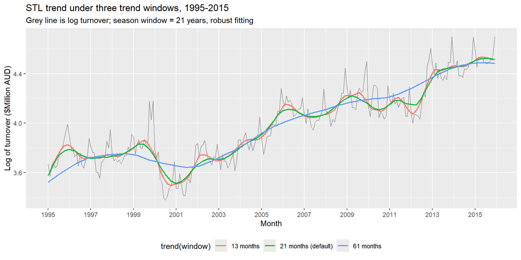

Figure 9

```r
trend_windows <- c("13 months" = 13, "21 months (default)" = 21, "61 months" = 61)

trend_cmp <- purrr::imap(trend_windows, \(tw, nm) fit_stl(tw, 21) |> mutate(window = nm))

trend_cmp |>
  purrr::map(as_tibble) |>
  bind_rows() |>
  filter(year(Month) >= 1995, year(Month) <= 2015) |>
  mutate(window = factor(window, levels = names(trend_windows))) |>
  ggplot(aes(x = Month)) +
  geom_line(aes(y = `box_cox(Turnover, lambda)`), colour = "grey60") +
  geom_line(aes(y = trend, colour = window), linewidth = 0.8) +
  scale_x_yearmonth(date_breaks = "2 years", date_labels = "%Y") +
  labs(
    title = "STL trend under three trend windows, 1995-2015",
    subtitle = "Grey line is log turnover; season window = 21 years, robust fitting",
    x = "Month",
    y = "Log of turnover ($Million AUD)",
    colour = "trend(window)"
  ) +
  theme(legend.position = "bottom")
```

**Trend window: 13 months.** The series moves in steps, which a 61-month trend cuts straight through and the 21-month default lags behind. A 13-month trend follows the 2000 drop and the 2013 jump within a few months. It is also the shortest window that spans a full year, so the trend cannot absorb the seasonal pattern.

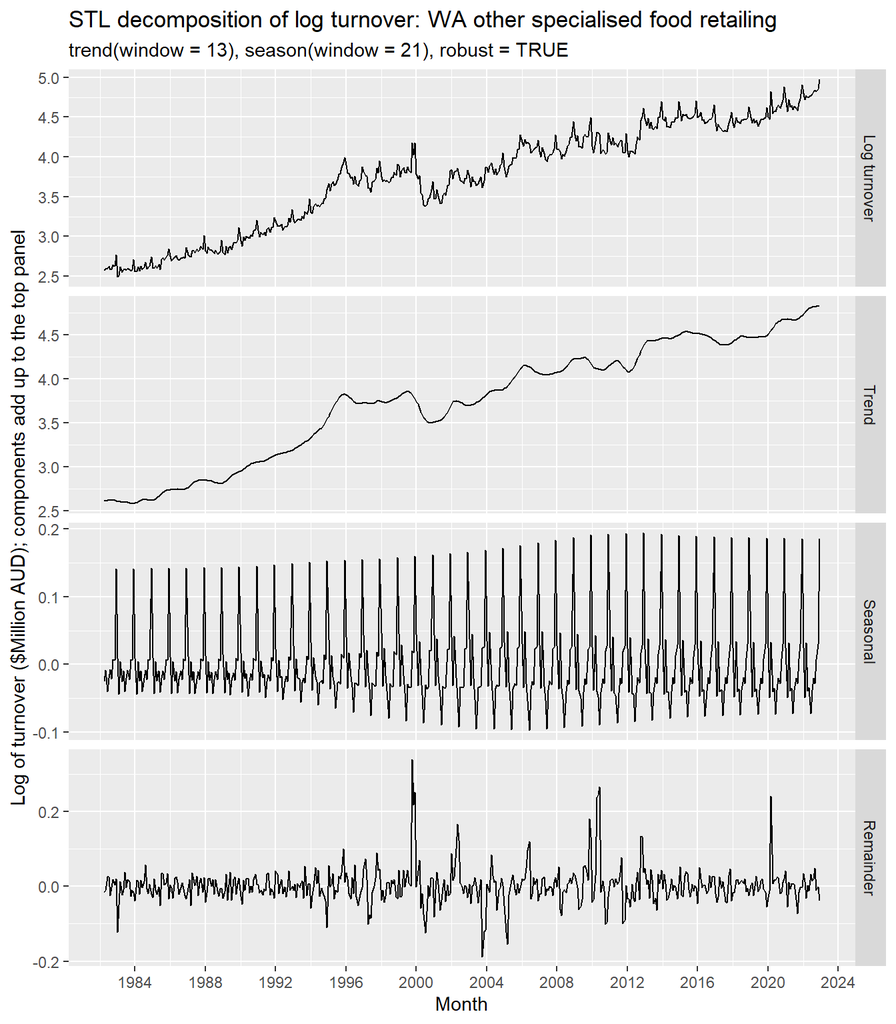

Figure 10

```r
stl_final <- fit_stl(trend_window = 13, season_window = 21)

# Built by hand so the panels have readable names instead of column names
stl_final |>
  as_tibble() |>
  select(Month, `Log turnover` = `box_cox(Turnover, lambda)`, Trend = trend, Seasonal = season_year, Remainder = remainder) |>
  tidyr::pivot_longer(-Month, names_to = "component") |>
  mutate(component = factor(component, levels = c("Log turnover", "Trend", "Seasonal", "Remainder"))) |>
  ggplot(aes(x = Month, y = value)) +
  geom_line() +
  facet_grid(rows = vars(component), scales = "free_y") +
  scale_x_yearmonth(date_breaks = "4 years", date_labels = "%Y") +
  labs(
    title = paste("STL decomposition of log turnover:", series_name),
    subtitle = "trend(window = 13), season(window = 21), robust = TRUE",
    x = "Month",
    y = "Log of turnover ($Million AUD); components add up to the top panel"
  )
```

The trend grows at a fairly steady percentage rate apart from the steps in Section 1. The December effect rose from about 15% to 21% above trend, so the models should let the seasonal pattern evolve. The largest remainders are the months already explained (Y2K, April-June 2010, March 2020), and the remainder is noisier before 2012, which may make the prediction intervals wider than recent data need.

# 5. Differencing and unit-root tests

```r
train <- retail |>
  filter(Month <= max(Month) - 24)
```

The last 24 months (2021 Jan to 2022 Dec) are held back as a test set, so the tests below use the training set. ARIMA needs a stationary series, so I chose the differencing using the KPSS test, whose null hypothesis is that the series is stationary (p < 0.05 means difference again), alongside the ACF.

```r
# ACF and PACF in one labelled, faceted plot
acf_pacf_plot <- function(.data, var, lag_max = 36, title, subtitle = NULL) {
  n_obs <- .data |>
    mutate(.v = {{ var }}) |>
    pull(.v) |>
    na.omit() |>
    length()
  bind_rows(
    .data |> ACF({{ var }}, lag_max = lag_max) |> as_tibble() |>
      transmute(lag = as.numeric(lag), value = acf, type = "ACF"),
    .data |> PACF({{ var }}, lag_max = lag_max) |> as_tibble() |>
      transmute(lag = as.numeric(lag), value = pacf, type = "PACF")
  ) |>
    ggplot(aes(x = lag, y = value)) +
    geom_segment(aes(xend = lag, yend = 0)) +
    geom_hline(yintercept = 0) +
    geom_hline(yintercept = c(-1, 1) * 1.96 / sqrt(n_obs), linetype = "dashed", colour = "blue") +
    facet_wrap(vars(type), ncol = 1) +
    scale_x_continuous(breaks = seq(0, lag_max, by = 6)) +
    labs(title = title, subtitle = subtitle, x = "Lag (months)", y = "Correlation")
}
```

```r
seasonal_test <- train |>
  features(box_cox(Turnover, lambda), list(unitroot_nsdiffs, feat_stl)) |>
  select(nsdiffs, seasonal_strength_year)
seasonal_test |>
  knitr::kable(digits = 3, col.names = c("nsdiffs", "Seasonal strength (log scale)"))
```

| nsdiffs | Seasonal strength (log scale) |
| --- | --- |
| 0 | 0.626 |

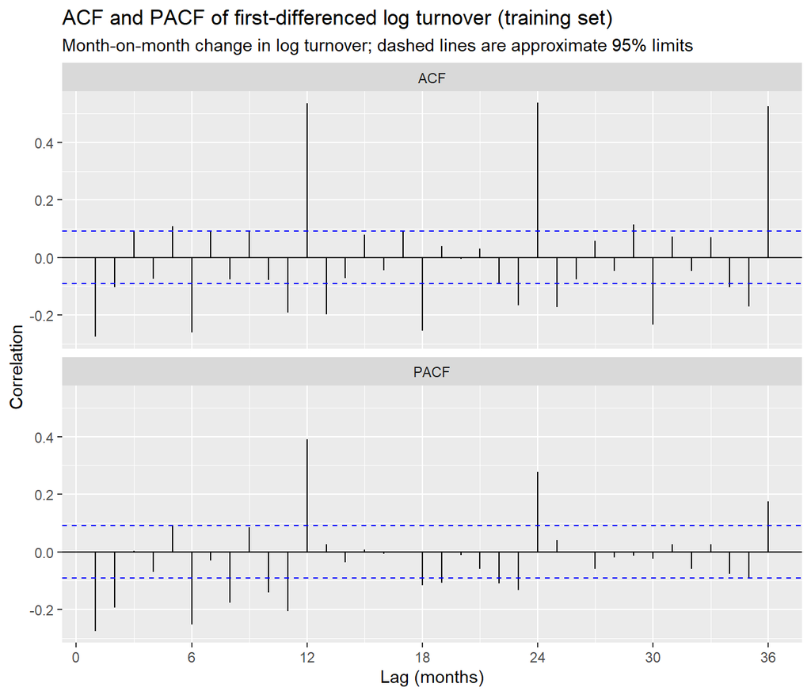

Figure 11

```r
train |>
  acf_pacf_plot(
    difference(box_cox(Turnover, lambda)),
    title = "ACF and PACF of first-differenced log turnover (training set)",
    subtitle = "Month-on-month change in log turnover; dashed lines are approximate 95% limits"
  )
```

**Seasonal difference (D = 1).** `unitroot_nsdiffs` recommends 0 seasonal differences only because the seasonal strength (0.626) is just under its 0.64 cut-off. That is too close to call, and the seasonal spikes in the ACF above do not die away (0.54, 0.54 and 0.53 at lags 12, 24 and 36), so I took a seasonal difference anyway.

```r
kpss_results <- bind_rows(
  "log(Turnover)" = train |> features(box_cox(Turnover, lambda), unitroot_kpss),
  "Seasonally differenced" = train |> features(difference(box_cox(Turnover, lambda), 12), unitroot_kpss),
  "Seasonally and first differenced" = train |> features(difference(difference(box_cox(Turnover, lambda), 12)), unitroot_kpss),
  .id = "Series"
) |>
  select(Series, kpss_stat, kpss_pvalue)

ndiffs_after_seasonal <- train |>
  features(difference(box_cox(Turnover, lambda), 12), unitroot_ndiffs) |>
  pull(ndiffs)

kpss_results |>
  knitr::kable(digits = 3, col.names = c("Series", "KPSS statistic", "KPSS p-value"))
```

| Series | KPSS statistic | KPSS p-value |
| --- | --- | --- |
| log(Turnover) | 7.408 | 0.01 |
| Seasonally differenced | 0.092 | 0.10 |
| Seasonally and first differenced | 0.016 | 0.10 |

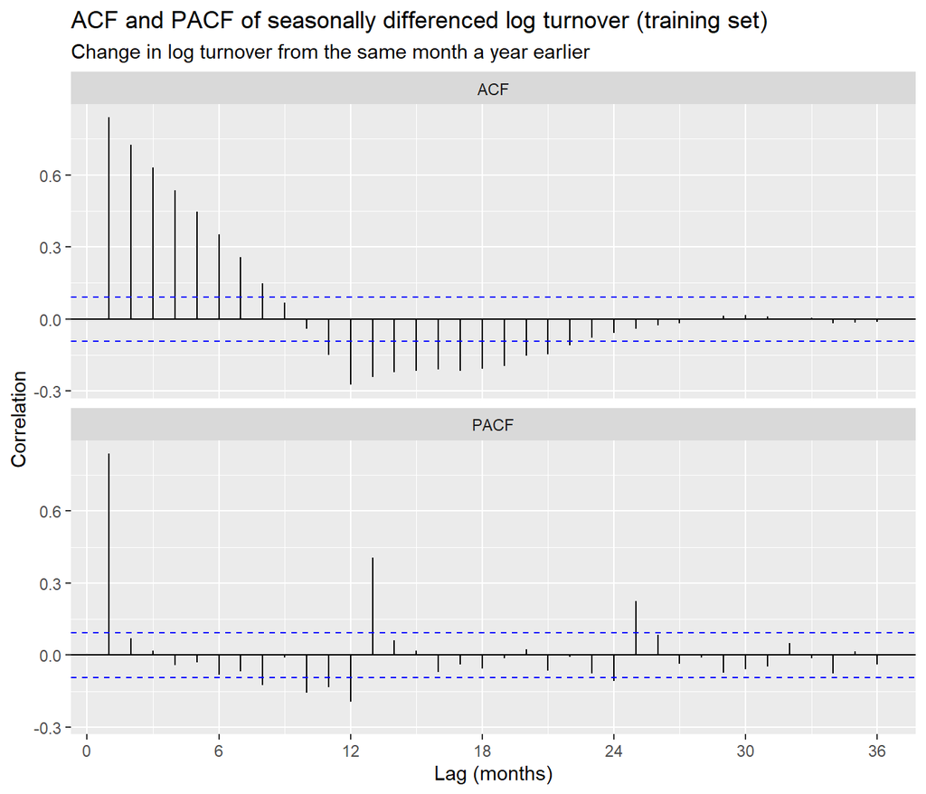

Figure 12

```r
train |>
  acf_pacf_plot(
    difference(box_cox(Turnover, lambda), 12),
    title = "ACF and PACF of seasonally differenced log turnover (training set)",
    subtitle = "Change in log turnover from the same month a year earlier"
  )
```

**First difference (d = 1).** Log turnover fails the KPSS test (p = 0.01 or smaller), and after the seasonal difference it passes (p = 0.1 or larger), with `unitroot_ndiffs` suggesting 0 more differences. However, the ACF of the seasonally differenced series (roughly annual growth) starts at 0.84 and decays slowly, so growth drifts away from its average for years at a time. Stopping at d = 0 would assume growth always returns to one fixed rate, which does not fit the distinct growth phases in Section 1, so I also took a first difference. The lag-1 autocorrelation after both differences is only -0.15 (about -0.5 would signal over-differencing), and because KPSS supported d = 0, one d = 0 model is kept in Section 6 as a check.

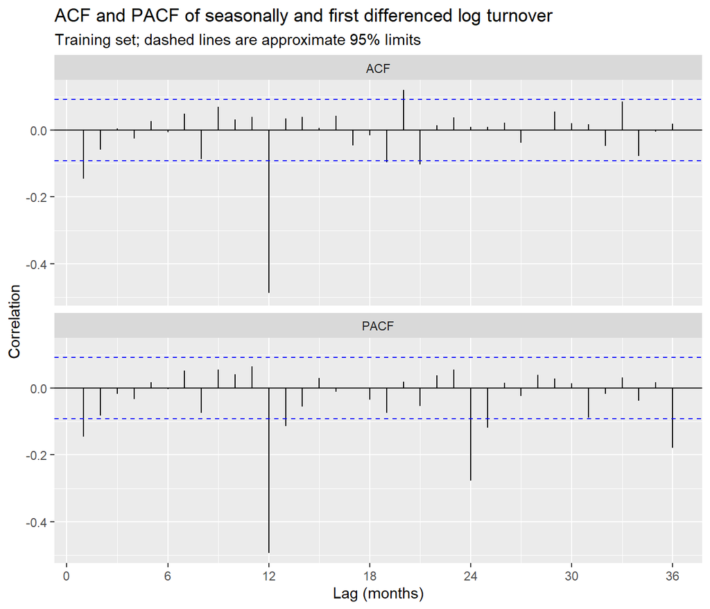

Figure 13

```r
train |>
  acf_pacf_plot(
    difference(difference(box_cox(Turnover, lambda), 12)),
    title = "ACF and PACF of seasonally and first differenced log turnover",
    subtitle = "Training set; dashed lines are approximate 95% limits"
  )
```

# 6. Short-listing ARIMA and ETS models

I proposed candidates from the ACF and PACF above and checked them against automatic searches, then fitted all of them to the training set. AICc is only compared between models with the **same differencing** (ARIMA) or on the **same scale** (ETS), because otherwise the likelihoods are computed on different data. **AICc cannot compare ARIMA with ETS**, so those comparisons use test-set accuracy instead.

## ARIMA candidates

The double-differenced ACF and PACF have a spike at lag 1, suggesting an MA(1) term, and a single seasonal ACF spike at lag 12 with decaying seasonal PACF spikes, suggesting a seasonal MA(1). **Constant:** with d + D = 2 no constant is used, because it would make growth accelerate without limit (a quadratic trend). With d + D = 1 a constant (drift) is needed, or the forecasts would stop growing.

```r
arima_fit <- train |>
  model(
    arima_011_011 = ARIMA(box_cox(Turnover, lambda) ~ 0 + pdq(0, 1, 1) + PDQ(0, 1, 1)),
    arima_auto_full = ARIMA(box_cox(Turnover, lambda) ~ pdq(d = 1) + PDQ(D = 1),
      stepwise = FALSE, approximation = FALSE
    ),
    arima_100_011_drift = ARIMA(box_cox(Turnover, lambda) ~ 1 + pdq(1, 0, 0) + PDQ(0, 1, 1))
  )
```

```r
arima_glance <- glance(arima_fit) |> select(.model, AICc)
arima_fc <- arima_fit |> forecast(h = 24)
arima_acc <- arima_fc |>
  accuracy(retail) |>
  select(.model, RMSE, MAE, MAPE, MASE)

arima_summary <- arima_fit |>
  as_tibble() |>
  select(-State, -Industry) |>
  tidyr::pivot_longer(everything(), names_to = ".model", values_to = "fit") |>
  mutate(
    Specification = purrr::map_chr(fit, format),
    Differencing = if_else(.model == "arima_100_011_drift", "d = 0, D = 1", "d = 1, D = 1")
  ) |>
  select(.model, Specification, Differencing) |>
  left_join(arima_glance, by = ".model") |>
  left_join(arima_acc, by = ".model")

arima_summary |>
  knitr::kable(digits = 2, caption = "ARIMA candidates: AICc on the log training data; test-set accuracy in $Million AUD (MAPE in %)")
```

ARIMA candidates: AICc on the log training data; test-set accuracy in $Million AUD (MAPE in %)

| .model | Specification | Differencing | AICc | RMSE | MAE | MAPE | MASE |
| --- | --- | --- | --- | --- | --- | --- | --- |
| arima_011_011 | ARIMA(0,1,1)(0,1,1)[12] | d = 1, D = 1 | -1242.97 | 6.49 | 5.42 | 4.97 | 0.93 |
| arima_auto_full | ARIMA(0,1,1)(2,1,0)[12] | d = 1, D = 1 | -1153.66 | 16.01 | 14.82 | 13.03 | 2.54 |
| arima_100_011_drift | ARIMA(1,0,0)(0,1,1)[12] w/ drift | d = 0, D = 1 | -1237.98 | 8.11 | 6.85 | 6.25 | 1.18 |

**Why each was included:**

- **ARIMA(0,1,1)(0,1,1)<sub>12</sub>:** read directly from the lag-1 and lag-12 ACF spikes.
- **Automatic search with d = 1, D = 1 (`stepwise = FALSE`):** a check on the hand-picked orders. It chose **ARIMA(0,1,1)(2,1,0)[12]**, and the default stepwise search chose the same model.
- **ARIMA(1,0,0)(0,1,1)<sub>12</sub> with drift:** the d = 0 differencing that KPSS supported, to test my choice of d = 1.

**ARIMA(0,1,1)(0,1,1)<sub>12</sub>** has a much lower AICc than the automatic choice (-1243 against -1153.7, same differencing). The search missed it because `fable` rules out a seasonal MA coefficient this close to -1, yet the model is valid and fits better, which is why I used automatic selection only as a check. The d = 0 model cannot be compared on AICc, but it does worse on the test set (MAPE 6.3% against 5%), which supports taking a first difference in Section 5.

**Left out:** ARIMA(1,1,0)(0,1,1)<sub>12</sub>, because the single small lag-1 spike fits an MA(1) or AR(1) almost equally well, so only one version is needed; models without a seasonal difference, such as the fully automatic `ARIMA()`, because Section 5 showed the seasonality needs one; a constant with d = 1, D = 1 (accelerating growth); extra seasonal terms (only one seasonal spike); and larger p or q (the remaining spikes are small and isolated).

## ETS candidates

ETS models are labelled (Error, Trend, Season), with each part None (N), Additive (A), damped (Ad) or Multiplicative (M). All candidates use log turnover, the same scale as ARIMA, where additive seasonality means a December peak that is a fixed percentage of the level.

```r
ets_fit <- train |>
  model(
    ets_log_AAA = ETS(box_cox(Turnover, lambda) ~ error("A") + trend("A") + season("A")),
    ets_log_AAdA = ETS(box_cox(Turnover, lambda) ~ error("A") + trend("Ad") + season("A")),
    ets_log_auto = ETS(box_cox(Turnover, lambda))
  )
```

```r
ets_glance <- glance(ets_fit) |> select(.model, AICc)
ets_fc <- ets_fit |> forecast(h = 24)
ets_acc <- ets_fc |>
  accuracy(retail) |>
  select(.model, RMSE, MAE, MAPE, MASE)

ets_summary <- ets_fit |>
  as_tibble() |>
  select(-State, -Industry) |>
  tidyr::pivot_longer(everything(), names_to = ".model", values_to = "fit") |>
  mutate(Specification = purrr::map_chr(fit, format)) |>
  select(.model, Specification) |>
  left_join(ets_glance, by = ".model") |>
  left_join(ets_acc, by = ".model")

ets_summary |>
  knitr::kable(digits = 2, caption = "ETS candidates: AICc on the log training data; test-set accuracy in $Million AUD (MAPE in %)")
```

ETS candidates: AICc on the log training data; test-set accuracy in $Million AUD (MAPE in %)

| .model | Specification | AICc | RMSE | MAE | MAPE | MASE |
| --- | --- | --- | --- | --- | --- | --- |
| ets_log_AAA | ETS(A,A,A) | 268.48 | 5.88 | 4.94 | 4.48 | 0.85 |
| ets_log_AAdA | ETS(A,Ad,A) | 299.49 | 7.38 | 6.44 | 5.65 | 1.11 |
| ets_log_auto | ETS(M,Ad,A) | 207.99 | 6.86 | 5.63 | 5.16 | 0.97 |

**Why each was included:**

- **ETS(A,A,A):** steady percentage growth, matching the long-run log trend.
- **ETS(A,Ad,A):** tests whether growth is likely to slow down.
- **Automatic `ETS()`:** a check on the hand-picked models. It chose **ETS(M,Ad,A)**.

The automatic ETS(M,Ad,A) has the lowest AICc (208), but almost all of that advantage comes from its multiplicative errors, which most likely just soak up the volatile 1995-2013 period. On the test set, **ETS(A,A,A)** is the most accurate (MAPE 4.48% against 5.16% for the automatic model and 5.65% for the damped one), because turnover kept growing rather than slowing down.

**Left out:** a no-trend model, because the series has clear long-run growth; models on raw turnover with multiplicative seasonality, because on the log scale the seasonality is already multiplicative in $Million AUD; multiplicative seasonality on the log scale (it would double-count the log); multiplicative trends (runaway growth); and non-seasonal models (there is a clear December peak). Benchmarks are not short-listed, but MASE compares each model with a seasonal naive forecast.

## Forecasts from the candidates

```r
model_labels <- bind_rows(
  arima_summary |> select(.model, Specification),
  ets_summary |> select(.model, Specification)
) |>
  mutate(Label = case_when(
    .model == "arima_auto_full" ~ paste(Specification, "(automatic)"),
    .model == "ets_log_auto" ~ paste(Specification, "(automatic)"),
    .default = Specification
  )) |>
  mutate(Label = factor(Label, levels = Label))

plot_candidate_fc <- function(fc, title) {
  fc |>
    left_join(model_labels |> select(.model, Label), by = ".model") |>
    autoplot(retail |> filter(year(Month) >= 2017), level = c(80, 95)) +
    geom_vline(xintercept = max(train$Month), linetype = "dashed", colour = "grey40") +
    facet_wrap(vars(Label), ncol = 1) +
    scale_x_yearmonth(date_breaks = "1 year", date_labels = "%Y") +
    # Each panel is already labelled with its model, so the colour legend is redundant
    guides(colour = "none", fill = "none", fill_ramp = guide_legend(title = "Prediction interval")) +
    theme(legend.position = "bottom") +
    labs(
      title = title,
      subtitle = "Black line is actual turnover; dashed line marks the end of the training set (December 2020)",
      x = "Month",
      y = y_lab
    )
}
```

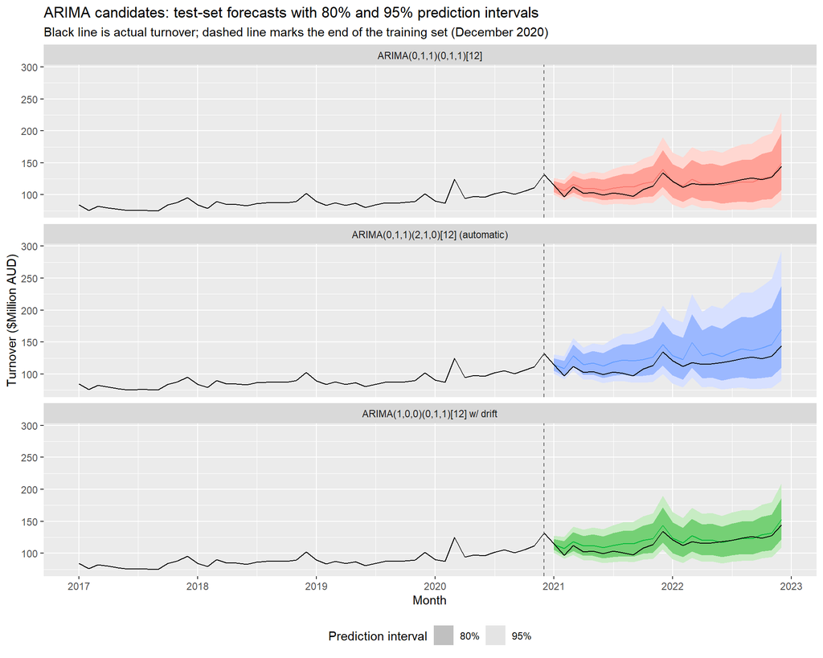

Figure 14

```r
plot_candidate_fc(arima_fc, "ARIMA candidates: test-set forecasts with 80% and 95% prediction intervals")
```

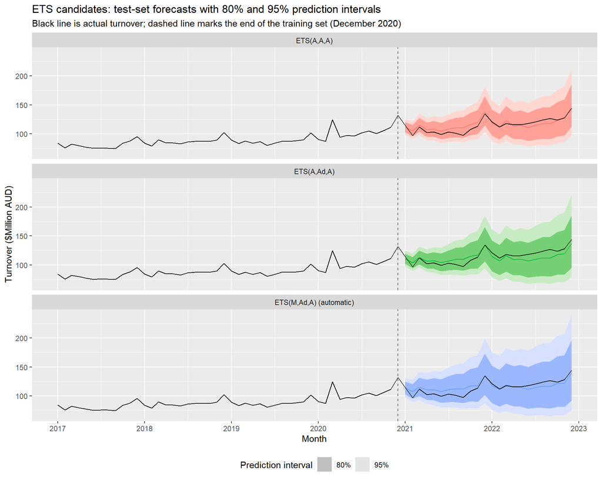

Figure 15

```r
plot_candidate_fc(ets_fc, "ETS candidates: test-set forecasts with 80% and 95% prediction intervals")
```

```r
actual_test <- retail |>
  as_tibble() |>
  filter(Month > max(train$Month)) |>
  select(Month, Actual = Turnover)

fc_check <- bind_rows(as_tibble(arima_fc), as_tibble(ets_fc)) |>
  mutate(pi80 = hilo(Turnover, 80), pi95 = hilo(Turnover, 95)) |>
  left_join(actual_test, by = "Month") |>
  mutate(
    in80 = Actual >= pi80$lower & Actual <= pi80$upper,
    in95 = Actual >= pi95$lower & Actual <= pi95$upper,
    width95 = pi95$upper - pi95$lower
  )

interval_summary <- fc_check |>
  group_by(.model) |>
  summarise(
    mean_error = mean(Actual - .mean),
    fc_2021 = mean(.mean[year(Month) == 2021]),
    fc_2022 = mean(.mean[year(Month) == 2022]),
    cover80 = 100 * mean(in80),
    cover95 = 100 * mean(in95),
    width95 = mean(width95)
  ) |>
  left_join(model_labels |> select(.model, Label), by = ".model") |>
  arrange(match(.model, model_labels$.model))

interval_summary |>
  select(Label, mean_error, fc_2021, fc_2022, cover80, cover95, width95) |>
  knitr::kable(
    digits = 1,
    col.names = c(
      "Model", "Mean error (actual - forecast)", "Mean forecast 2021", "Mean forecast 2022",
      "Actuals inside 80% PI (%)", "Actuals inside 95% PI (%)", "Mean width of 95% PI"
    ),
    caption = paste0(
      "Test-set forecasts in $Million AUD. Actual mean monthly turnover was $",
      round(mean(actual_test$Actual[year(actual_test$Month) == 2021]), 1), "M in 2021 and $",
      round(mean(actual_test$Actual[year(actual_test$Month) == 2022]), 1), "M in 2022."
    )
  )
```

Test-set forecasts in $Million AUD. Actual mean monthly turnover was $107.2M in 2021 and $122.2M in 2022.

| Model | Mean error (actual - forecast) | Mean forecast 2021 | Mean forecast 2022 | Actuals inside 80% PI (%) | Actuals inside 95% PI (%) | Mean width of 95% PI |
| --- | --- | --- | --- | --- | --- | --- |
| ARIMA(0,1,1)(0,1,1)[12] | -3.9 | 114.7 | 122.5 | 100.0 | 100 | 76.5 |
| ARIMA(0,1,1)(2,1,0)[12] (automatic) | -14.8 | 121.1 | 138.0 | 91.7 | 100 | 102.4 |
| ARIMA(1,0,0)(0,1,1)[12] w/ drift | -6.3 | 116.7 | 125.4 | 100.0 | 100 | 67.3 |
| ETS(A,A,A) | -1.8 | 113.1 | 120.0 | 100.0 | 100 | 64.9 |
| ETS(A,Ad,A) | 1.9 | 111.4 | 114.3 | 100.0 | 100 | 77.0 |
| ETS(M,Ad,A) (automatic) | -1.7 | 114.3 | 118.5 | 100.0 | 100 | 94.1 |

**Comparing the forecasts.** ARIMA(0,1,1)(0,1,1)<sub>12</sub> and ETS(A,A,A) both follow the seasonal shape closely but **over-forecast 2021** (for example, $114.7M against an actual $107.2M for ARIMA), because they carry forward the post-COVID level at the end of the training data. The automatic ARIMA climbs far too steeply ($138M in 2022 against $122.2M), because its seasonal AR terms repeat the 2020 jump, and the d = 0 model sits above the airline model throughout. The damped ETS model flattens out and misses the 2022 rise ($114.3M). The intervals are cautious: 5 of 6 candidates contain every test month in their 80% interval, when about 80% would be expected, because the variance is estimated from the volatile training years.

**Preferred forecast: ETS(A,A,A) on log turnover.** It is the most accurate, has a small bias ($1.8M a month) and has among the narrowest intervals while still containing every actual value. **ARIMA(0,1,1)(0,1,1)<sub>12</sub>** is the best ARIMA forecast, with the lowest AICc and the best test accuracy of its group. These two models are carried forward, and because both are on the log scale they can be compared directly in Section 8.

# 7. The chosen ARIMA and ETS models

```r
fit_arima <- arima_fit |> select(State, Industry, arima_011_011)
fit_ets <- ets_fit |> select(State, Industry, ets_log_AAA)
```

```r
# Small numbers in the text, without scientific notation
num <- \(x) format(signif(x, 2), scientific = FALSE)

# Time plot, ACF and histogram of the innovation residuals, each with its own labels
resid_plots <- function(fit, model_name) {
  res <- augment(fit)
  list(
    res |>
      autoplot(.innov) +
      geom_point(size = 0.5) +
      scale_x_yearmonth(date_breaks = "4 years", date_labels = "%Y") +
      labs(
        title = paste("Innovation residuals:", model_name),
        subtitle = "Log scale, so a residual of 0.1 is roughly a 10% forecast error",
        x = "Month",
        y = "Residual (log turnover)"
      ),
    res |>
      ACF(.innov, lag_max = 36) |>
      autoplot() +
      labs(title = "ACF of residuals", subtitle = model_name, x = "Lag (months)", y = "Autocorrelation"),
    res |>
      ggplot(aes(x = .innov)) +
      geom_histogram(aes(y = after_stat(density)), bins = 40, fill = "grey60") +
      stat_function(
        fun = dnorm, colour = "firebrick",
        args = list(mean = mean(res$.innov, na.rm = TRUE), sd = sd(res$.innov, na.rm = TRUE))
      ) +
      labs(
        title = "Histogram of residuals",
        subtitle = paste0(model_name, "; red curve is a normal distribution with the same mean and SD"),
        x = "Residual (log turnover)",
        y = "Density"
      )
  )
}

resid_summary <- function(fit) {
  res <- augment(fit) |> as_tibble()
  z <- (res$.innov - mean(res$.innov)) / sd(res$.innov)
  tibble(
    mean = mean(res$.innov),
    sd = sd(res$.innov),
    kurtosis = mean(z^4),
    sd_before_2012 = sd(res$.innov[year(res$Month) < 2012]),
    sd_from_2012 = sd(res$.innov[year(res$Month) >= 2012])
  )
}
```

## ARIMA(0,1,1)(0,1,1)<sub>12</sub> on log turnover

### Parameter estimates

```r
report(fit_arima)
```

```
Series: Turnover
Model: ARIMA(0,1,1)(0,1,1)[12]
Transformation: box_cox(Turnover, lambda)

Coefficients:
          ma1     sma1
      -0.2251  -0.9456
s.e.   0.0468   0.0330

sigma^2 estimated as 0.003496:  log likelihood=624.51
AIC=-1243.02   AICc=-1242.97   BIC=-1230.68
```

The two coefficients say how much of each forecast error (a “surprise”) the model keeps:

- **Non-seasonal MA, $\theta_1 =$ -0.225.** About 77% of an unexpected change in turnover is treated as a lasting change in level, and the remaining 23% is expected to reverse the next month.
- **Seasonal MA, $\Theta_1 =$ -0.946.** Only about 5% of a surprise in a given month (say an unusually strong December) carries into that month next year. The seasonal pattern therefore changes very slowly, matching the gradual change found with the 21-year STL window.
- Both are at least 4.8 standard errors from zero, so both are needed. A typical one-month-ahead error is about 5.9%.

For the forecasts to be reliable, the residuals should be uncorrelated with mean zero, and for the intervals they should also be roughly normal with constant variance.

### Residual diagnostics

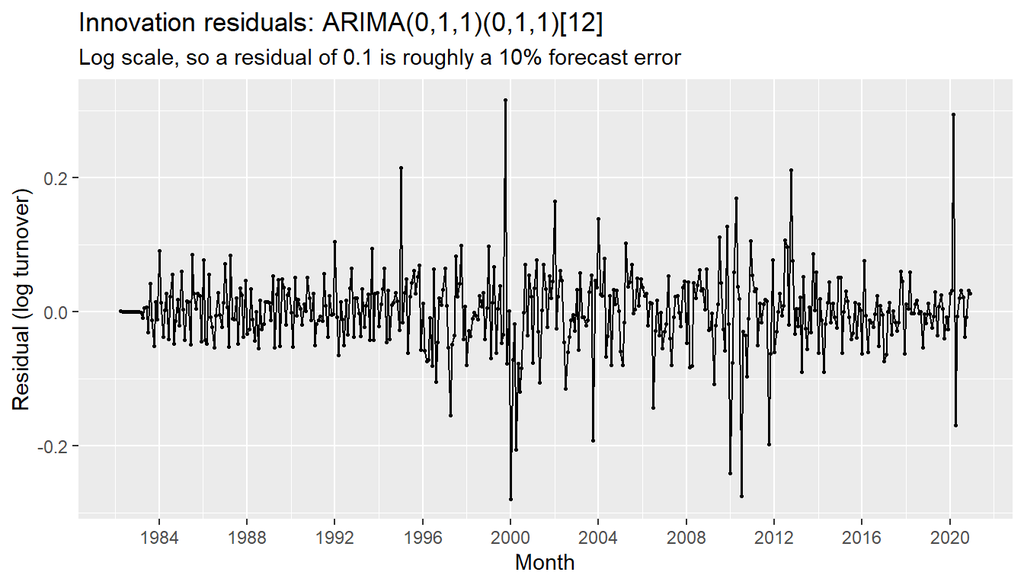

Figure 16

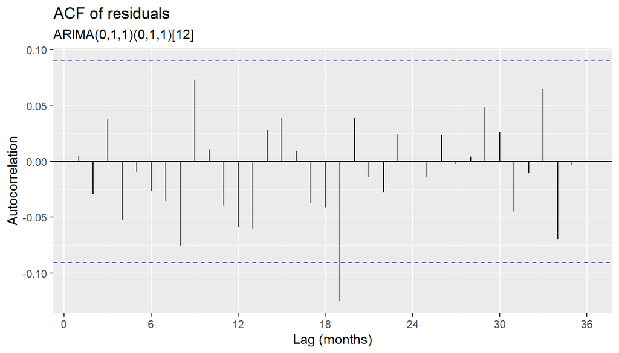

Figure 17

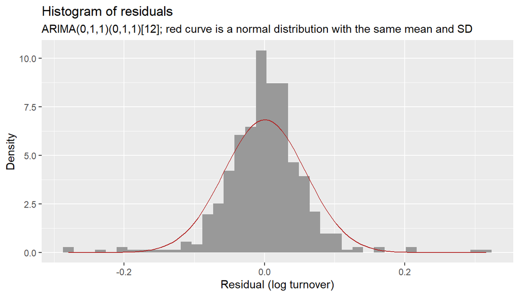

Figure 18

```r
resid_plots(fit_arima, "ARIMA(0,1,1)(0,1,1)[12]") |> purrr::walk(print)
```

```r
lb_arima <- augment(fit_arima) |>
  features(.innov, ljung_box, lag = 24, dof = k_arima)
lb_arima |>
  select(.model, lb_stat, lb_pvalue) |>
  knitr::kable(digits = 3, col.names = c("Model", "Ljung-Box statistic", "p-value"))
```

| Model | Ljung-Box statistic | p-value |
| --- | --- | --- |
| arima_011_011 | 24.722 | 0.311 |

```r
residual_reasons <- tribble(
  ~Month, ~Reason,
  "1995 Jan", "Start of the mid-1990s step up in level (episode A)",
  "1999 Oct", "Y2K stockpiling",
  "2000 Jan", "Fall back after the Y2K and millennium stockpiling",
  "2000 Apr", "Start of the 2000 collapse in the lead-up to the GST",
  "2010 Jan", "Fall back after the unusually strong spending of late 2009",
  "2010 Jul", "End of the temporary April-June 2010 jump (possibly an ABS sample change)",
  "2012 Oct", "Start of the 2013 step up at the peak of the mining boom (episode D)",
  "2020 Mar", "COVID-19 panic buying"
) |>
  mutate(Month = yearmonth(Month))

big_resid <- bind_rows(
  augment(fit_arima) |> as_tibble() |> mutate(model = "ARIMA"),
  augment(fit_ets) |> as_tibble() |> mutate(model = "ETS")
) |>
  select(model, Month, .innov) |>
  tidyr::pivot_wider(names_from = model, values_from = .innov) |>
  slice_max(abs(ARIMA), n = 8) |>
  left_join(residual_reasons, by = "Month")

big_resid |>
  mutate(Month = format(Month)) |>
  knitr::kable(
    digits = 3,
    col.names = c("Month", "ARIMA residual", "ETS residual", "Likely reason"),
    caption = "The eight largest ARIMA residuals (log scale), with the ETS residual for the same month"
  )
```

The eight largest ARIMA residuals (log scale), with the ETS residual for the same month

| Month | ARIMA residual | ETS residual | Likely reason |
| --- | --- | --- | --- |
| 1999 Oct | 0.316 | 0.301 | Y2K stockpiling |
| 2020 Mar | 0.294 | 0.295 | COVID-19 panic buying |
| 2000 Jan | -0.280 | -0.285 | Fall back after the Y2K and millennium stockpiling |
| 2010 Jul | -0.274 | -0.273 | End of the temporary April-June 2010 jump (possibly an ABS sample change) |
| 2010 Jan | -0.241 | -0.231 | Fall back after the unusually strong spending of late 2009 |
| 1995 Jan | 0.214 | 0.203 | Start of the mid-1990s step up in level (episode A) |
| 2012 Oct | 0.211 | 0.212 | Start of the 2013 step up at the peak of the mining boom (episode D) |
| 2000 Apr | -0.206 | -0.215 | Start of the 2000 collapse in the lead-up to the GST |

- **Time plot.** The residuals sit around zero (mean 0.00041) with no trend. Every large spike in the table above is a month already explained in Sections 1-2, which no model could predict from past turnover.
- **ACF.** Only 1 of 36 lags (lag 19) just crosses the limits, which is expected by chance, and nothing is left at lag 1 or the seasonal lags.
- **Ljung-Box test.** This checks the first 24 autocorrelations together (two years of monthly lags), with 2 degrees of freedom removed for the two estimated MA coefficients (p + q + P + Q). The p-value is 0.311, well above 0.05, so there is no evidence of remaining autocorrelation: **the residuals are consistent with white noise.**
- **Histogram.** Centred on zero but with long tails (kurtosis 9.3, against 3 for a normal distribution), caused by the one-off months.

**What this means.** The point forecasts use all the predictable pattern in past turnover. The long tails inflate the estimated spread, so the intervals will be *too wide* for ordinary months, but they may still be too narrow for rare shocks like COVID-19.

### Test-set forecasts

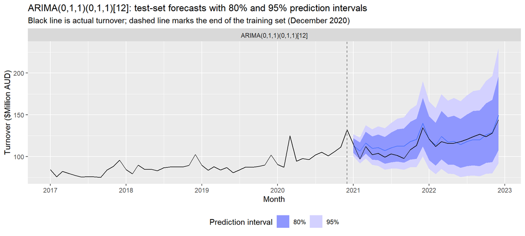

Figure 19

```r
arima_fc |>
  filter(.model == "arima_011_011") |>
  plot_candidate_fc("ARIMA(0,1,1)(0,1,1)[12]: test-set forecasts with 80% and 95% prediction intervals")
```

The forecasts match the seasonal shape closely but **over-forecast 2021** ($114.7M against $107.2M on average), because the model carries forward the post-COVID level while turnover eased back. By 2022, food-price inflation had brought turnover back up to the forecast path, and all 24 actual values lie inside the 80% intervals.

## ETS(A,A,A) on log turnover

### Parameter estimates

```r
report(fit_ets)
```

```
Series: Turnover
Model: ETS(A,A,A)
Transformation: box_cox(Turnover, lambda)
  Smoothing parameters:
    alpha = 0.6372603
    beta  = 0.00015485
    gamma = 0.06603988

  Initial states:
     l[0]        b[0]        s[0]       s[-1]      s[-2]     s[-3]      s[-4]
 2.631888 0.004192765 0.002796854 -0.03428409 0.03020286 0.1441418 0.04302352
      s[-5]       s[-6]      s[-7]       s[-8]       s[-9]      s[-10]
 0.05080789 -0.03132241 -0.0245572 -0.02222892 -0.07115265 -0.06413258
      s[-11]
 -0.02329503

  sigma^2:  0.0037

     AIC     AICc      BIC
267.1120 268.4811 337.5267
```

The three smoothing parameters say how quickly the level, growth rate and seasonal pattern react to surprises (0 = never, 1 = fully):

- **$\alpha =$ 0.637 (level).** About 64% of each surprise is absorbed into the level straight away. This suits a series that moves in sudden steps.
- **$\beta =$ 0.00015 (growth rate).** Essentially zero, so the model assumes a fixed long-run growth rate of about 5.2% a year, and booms and slumps move the level instead.
- **$\gamma =$ 0.066 (seasonality).** The seasonal pattern evolves slowly, with December rising from about 16% to 20% above the level, as STL found.

A typical one-month-ahead error is about 6.1%, almost the same as ARIMA. The residual assumptions are also the same.

### Residual diagnostics

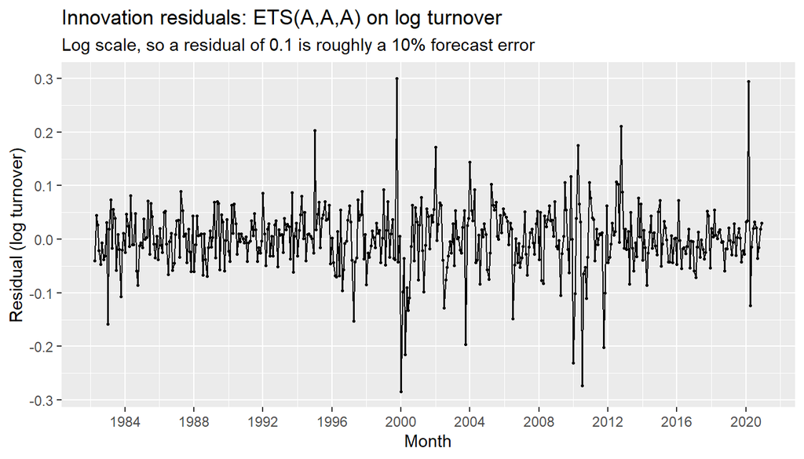

Figure 20

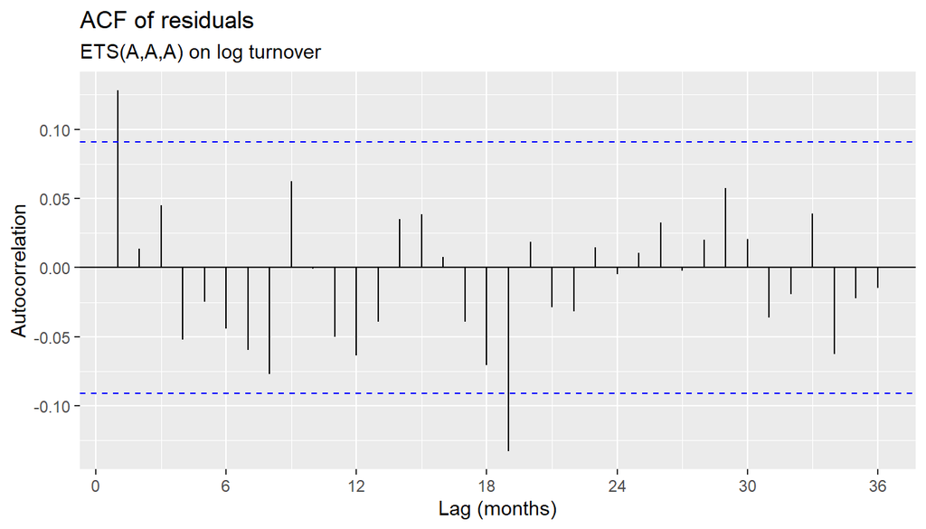

Figure 21

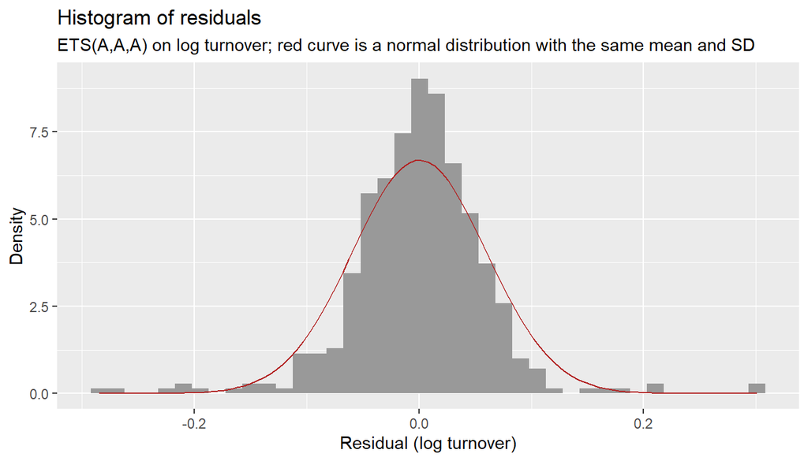

Figure 22

```r
resid_plots(fit_ets, "ETS(A,A,A) on log turnover") |> purrr::walk(print)
```

```r
k_ets <- 3 # alpha, beta and gamma, used only as a sensitivity check
lb_ets <- bind_rows(
  augment(fit_ets) |> features(.innov, ljung_box, lag = 24, dof = 0) |> mutate(dof = 0),
  augment(fit_ets) |> features(.innov, ljung_box, lag = 24, dof = k_ets) |> mutate(dof = k_ets)
)
lb_ets |>
  select(.model, dof, lb_stat, lb_pvalue) |>
  knitr::kable(digits = 3, col.names = c("Model", "Degrees of freedom removed", "Ljung-Box statistic", "p-value"))
```

| Model | Degrees of freedom removed | Ljung-Box statistic | p-value |
| --- | --- | --- | --- |
| ets_log_AAA | 0 | 35.754 | 0.058 |
| ets_log_AAA | 3 | 35.754 | 0.023 |

- **Time plot and histogram.** The same as ARIMA: centred on zero (mean 0.00034), with spikes at the same explained months and long tails (kurtosis 8.3).
- **ACF.** Unlike ARIMA, there is a **lag-1 autocorrelation of 0.13** (0.01 for ARIMA), so a month above forecast tends to be followed by another. ETS(A,A,A) has no term for this, whereas the ARIMA MA(1) term captures it.
- **Ljung-Box test.** I used 24 lags and, following the textbook convention for ETS, removed no degrees of freedom, giving p = 0.058, only just above 0.05. Removing 3 for the smoothing parameters gives p = 0.023, so the residuals are **borderline white noise**.

**What this means.** The leftover correlation is small (about 1.6% of the residual variance), so it barely affects forecasts beyond a month or two, but ETS leaves a little short-term information unused. As with ARIMA, the intervals are likely too wide for ordinary months.

### Test-set forecasts

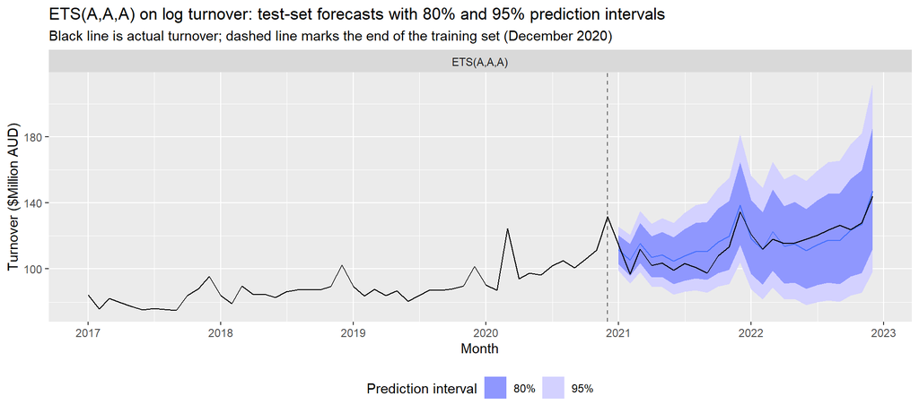

Figure 23

```r
ets_fc |>
  filter(.model == "ets_log_AAA") |>
  plot_candidate_fc("ETS(A,A,A) on log turnover: test-set forecasts with 80% and 95% prediction intervals")
```

Like ARIMA, the ETS forecasts match the seasonal shape and over-forecast 2021 ($113.1M against $107.2M). Its fixed growth rate rises more slowly than ARIMA’s, which helps in 2021 but leaves it slightly low in late 2022 ($120M against $122.2M). All 24 actual values lie inside the 80% intervals.

# 8. Comparing the two models on the test set

AICc cannot compare ARIMA with ETS, so the two models are compared on the 24 test months.

```r
chosen_ids <- c("arima_011_011", "ets_log_AAA")

test_compare <- bind_rows(arima_acc, ets_acc) |>
  filter(.model %in% chosen_ids) |>
  left_join(interval_summary |> select(.model, Label, mean_error, cover80, cover95, width95), by = ".model")

test_compare |>
  select(Label, RMSE, MAE, MAPE, MASE, mean_error, cover80, cover95, width95) |>
  knitr::kable(
    digits = 2,
    col.names = c(
      "Model", "RMSE", "MAE", "MAPE (%)", "MASE", "Mean error (actual - forecast)",
      "Actuals inside 80% PI (%)", "Actuals inside 95% PI (%)", "Mean width of 95% PI"
    ),
    caption = "Test-set accuracy, January 2021 to December 2022 ($Million AUD unless stated)"
  )
```

Test-set accuracy, January 2021 to December 2022 ($Million AUD unless stated)

| Model | RMSE | MAE | MAPE (%) | MASE | Mean error (actual - forecast) | Actuals inside 80% PI (%) | Actuals inside 95% PI (%) | Mean width of 95% PI |
| --- | --- | --- | --- | --- | --- | --- | --- | --- |
| ARIMA(0,1,1)(0,1,1)[12] | 6.49 | 5.42 | 4.97 | 0.93 | -3.86 | 100 | 100 | 76.47 |
| ETS(A,A,A) | 5.88 | 4.94 | 4.48 | 0.85 | -1.80 | 100 | 100 | 64.93 |

```r
rmse_by_year <- fc_check |>
  filter(.model %in% chosen_ids) |>
  group_by(.model, Year = year(Month)) |>
  summarise(RMSE = sqrt(mean((Actual - .mean)^2)), ME = mean(Actual - .mean), .groups = "drop") |>
  left_join(model_labels |> select(.model, Label), by = ".model")

rmse_by_year |>
  select(Label, Year, RMSE, ME) |>
  knitr::kable(
    digits = 2,
    col.names = c("Model", "Year", "RMSE ($Million AUD)", "Mean error (actual - forecast)"),
    caption = "Test-set accuracy by year"
  )
```

Test-set accuracy by year

| Model | Year | RMSE ($Million AUD) | Mean error (actual - forecast) |
| --- | --- | --- | --- |
| ARIMA(0,1,1)(0,1,1)[12] | 2021 | 8.42 | -7.46 |
| ARIMA(0,1,1)(0,1,1)[12] | 2022 | 3.66 | -0.25 |
| ETS(A,A,A) | 2021 | 6.94 | -5.84 |
| ETS(A,A,A) | 2022 | 4.56 | 2.23 |

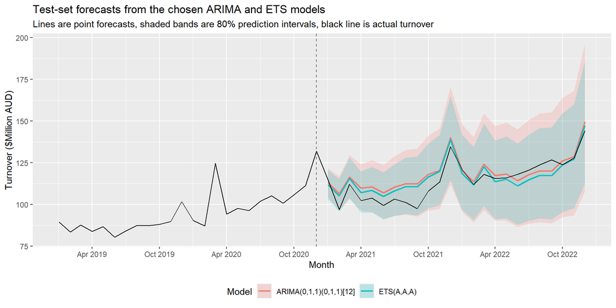

Figure 24

```r
fc_check |>
  filter(.model %in% chosen_ids) |>
  left_join(model_labels |> select(.model, Label), by = ".model") |>
  mutate(lower = pi80$lower, upper = pi80$upper) |>
  ggplot(aes(x = Month)) +
  geom_ribbon(aes(ymin = lower, ymax = upper, fill = Label), alpha = 0.2) +
  geom_line(aes(y = .mean, colour = Label), linewidth = 0.8) +
  geom_line(data = retail |> filter(year(Month) >= 2019), aes(y = Turnover), colour = "black") +
  geom_vline(xintercept = max(train$Month), linetype = "dashed", colour = "grey40") +
  scale_x_yearmonth(date_breaks = "6 months", date_labels = "%b %Y") +
  theme(legend.position = "bottom") +
  labs(
    title = "Test-set forecasts from the chosen ARIMA and ETS models",
    subtitle = "Lines are point forecasts, shaded bands are 80% prediction intervals, black line is actual turnover",
    x = "Month",
    y = y_lab,
    colour = "Model",
    fill = "Model"
  )
```

**Comparing the forecasts.** Both reproduce the seasonal pattern and over-forecast 2021. ARIMA grows slightly faster, which costs it in 2021 (RMSE 8.42 against 6.94) but helps in 2022 (3.66 against 4.56). The ETS intervals are narrower (mean 95% width $64.9M against $76.5M) because its growth rate is almost fixed, and both contain every actual value.

**I prefer ETS(A,A,A).** It is better on every accuracy measure (RMSE 5.88 against 6.49, MAPE 4.48% against 4.97%), less biased, and has sharper intervals with the same coverage. The margin is modest, though: it comes from only 24 months distorted by COVID-19, and ARIMA has the cleaner residuals, so both models are carried forward to Sections 9 and 10.

# 9. Forecasting two years ahead from the full data

## Refitting on all the data

To forecast beyond the end of the data, both models are re-estimated on the full series (April 1982 to December 2022), now including the two test years. The **model structures are fixed** exactly as chosen in Sections 6-8: the ARIMA orders are written into the formula with `0 +` (no constant), and the ETS components are fixed as (A,A,A), so no automatic selection is re-run. Only the parameters are re-estimated.

```r
fit_full <- retail |>
  model(
    arima = ARIMA(box_cox(Turnover, lambda) ~ 0 + pdq(0, 1, 1) + PDQ(0, 1, 1)),
    ets = ETS(box_cox(Turnover, lambda) ~ error("A") + trend("A") + season("A"))
  )

full_labels <- c(arima = "ARIMA(0,1,1)(0,1,1)[12]", ets = "ETS(A,A,A)")

param_compare <- bind_rows(
  tidy(fit_arima) |> mutate(Model = "ARIMA"),
  tidy(fit_ets) |> mutate(Model = "ETS")
) |>
  filter(term %in% c("ma1", "sma1", "alpha", "beta", "gamma")) |>
  select(Model, term, Training = estimate) |>
  left_join(
    tidy(fit_full) |> transmute(Model = toupper(.model), term, `Full data` = estimate),
    by = c("Model", "term")
  )

param_compare |>
  knitr::kable(
    digits = 4,
    col.names = c("Model", "Parameter", "Training set (to Dec 2020)", "Full data (to Dec 2022)"),
    caption = "Parameter estimates before and after adding the 2021-2022 data"
  )
```

Parameter estimates before and after adding the 2021-2022 data

| Model | Parameter | Training set (to Dec 2020) | Full data (to Dec 2022) |
| --- | --- | --- | --- |
| ARIMA | ma1 | -0.2251 | -0.2277 |
| ARIMA | sma1 | -0.9456 | -0.9492 |
| ETS | alpha | 0.6373 | 0.7646 |
| ETS | beta | 0.0002 | 0.0281 |
| ETS | gamma | 0.0660 | 0.0001 |

The **ARIMA estimates barely change** ($\theta_1$ from -0.225 to -0.228, $\Theta_1$ from -0.946 to -0.949), so it is essentially the same model with two more years of data. The two MA terms describe how much of each surprise carries over to the next month and to the same month next year, and the 2021-2022 data followed much the same pattern as the 465 training months. Adding 24 months that behave like the rest of the series therefore barely moves the estimates.

The **ETS estimates change noticeably**, even though the structure is the same:

- $\beta$ rises from about 0.00015 to 0.028. The growth rate is no longer fixed: it now adapts to recent data, so the strong 2021-2022 growth lifts the growth rate used for forecasting to about 7.1% a year (from 5.2% in the training fit).
- $\gamma$ falls to almost zero (0.00013), so the seasonal pattern is now held almost fixed at its recent shape.
- $\alpha$ rises from 0.637 to 0.765, so the level follows the latest data even more closely.

This shows ETS parameter estimates can be sensitive to a few unusual years at the end of the sample. The 2021-2022 period combined a post-COVID level shift with rapid food-price inflation, and fitting it pushed the model towards a more adaptive trend.

## Forecasts for 2023-2024

```r
fc_full <- fit_full |> forecast(h = 24)

fc_full_table <- fc_full |>
  hilo(level = 80) |>
  unpack_hilo(`80%`) |>
  as_tibble() |>
  select(.model, Month, .mean, lower = `80%_lower`, upper = `80%_upper`) |>
  tidyr::pivot_wider(names_from = .model, values_from = c(.mean, lower, upper))

fc_full_table |>
  mutate(Month = format(Month)) |>
  select(Month, .mean_arima, lower_arima, upper_arima, .mean_ets, lower_ets, upper_ets) |>
  knitr::kable(
    digits = 1,
    col.names = c(
      "Month", "ARIMA forecast", "ARIMA 80% lower", "ARIMA 80% upper",
      "ETS forecast", "ETS 80% lower", "ETS 80% upper"
    ),
    caption = "Point forecasts and 80% prediction intervals, $Million AUD"
  )
```

Point forecasts and 80% prediction intervals, $Million AUD

| Month | ARIMA forecast | ARIMA 80% lower | ARIMA 80% upper | ETS forecast | ETS 80% lower | ETS 80% upper |
| --- | --- | --- | --- | --- | --- | --- |
| 2023 Jan | 125.7 | 116.4 | 135.2 | 126.4 | 117.0 | 136.0 |
| 2023 Feb | 117.6 | 106.8 | 128.9 | 118.7 | 107.6 | 130.3 |
| 2023 Mar | 128.5 | 114.6 | 143.0 | 127.3 | 113.1 | 142.1 |
| 2023 Apr | 121.6 | 106.8 | 137.1 | 122.0 | 106.6 | 138.3 |
| 2023 May | 122.5 | 106.1 | 139.7 | 122.7 | 105.3 | 141.0 |
| 2023 Jun | 118.7 | 101.6 | 136.8 | 119.0 | 100.5 | 138.7 |
| 2023 Jul | 122.4 | 103.5 | 142.4 | 123.6 | 102.7 | 146.0 |
| 2023 Aug | 124.6 | 104.3 | 146.4 | 126.7 | 103.6 | 151.5 |
| 2023 Sep | 124.3 | 102.9 | 147.3 | 127.1 | 102.4 | 153.9 |
| 2023 Oct | 130.5 | 107.0 | 155.9 | 134.6 | 106.8 | 165.0 |
| 2023 Nov | 133.4 | 108.3 | 160.5 | 137.1 | 107.0 | 170.0 |
| 2023 Dec | 155.0 | 124.6 | 187.9 | 158.0 | 121.5 | 198.3 |
| 2024 Jan | 134.1 | 106.7 | 163.9 | 137.8 | 104.3 | 174.9 |
| 2024 Feb | 125.6 | 99.0 | 154.5 | 129.7 | 96.6 | 166.4 |
| 2024 Mar | 137.1 | 107.1 | 170.0 | 139.1 | 102.1 | 180.6 |
| 2024 Apr | 129.8 | 100.5 | 161.9 | 133.5 | 96.4 | 175.3 |
| 2024 May | 130.7 | 100.3 | 164.2 | 134.4 | 95.5 | 178.4 |
| 2024 Jun | 126.7 | 96.4 | 160.1 | 130.6 | 91.3 | 175.3 |
| 2024 Jul | 130.6 | 98.6 | 166.1 | 135.8 | 93.4 | 184.2 |
| 2024 Aug | 133.1 | 99.7 | 170.2 | 139.3 | 94.2 | 191.1 |
| 2024 Sep | 132.8 | 98.7 | 170.8 | 139.9 | 93.1 | 194.0 |
| 2024 Oct | 139.4 | 102.8 | 180.3 | 148.4 | 97.1 | 208.0 |
| 2024 Nov | 142.5 | 104.2 | 185.3 | 151.3 | 97.4 | 214.4 |
| 2024 Dec | 165.6 | 120.2 | 216.4 | 174.7 | 110.5 | 250.1 |

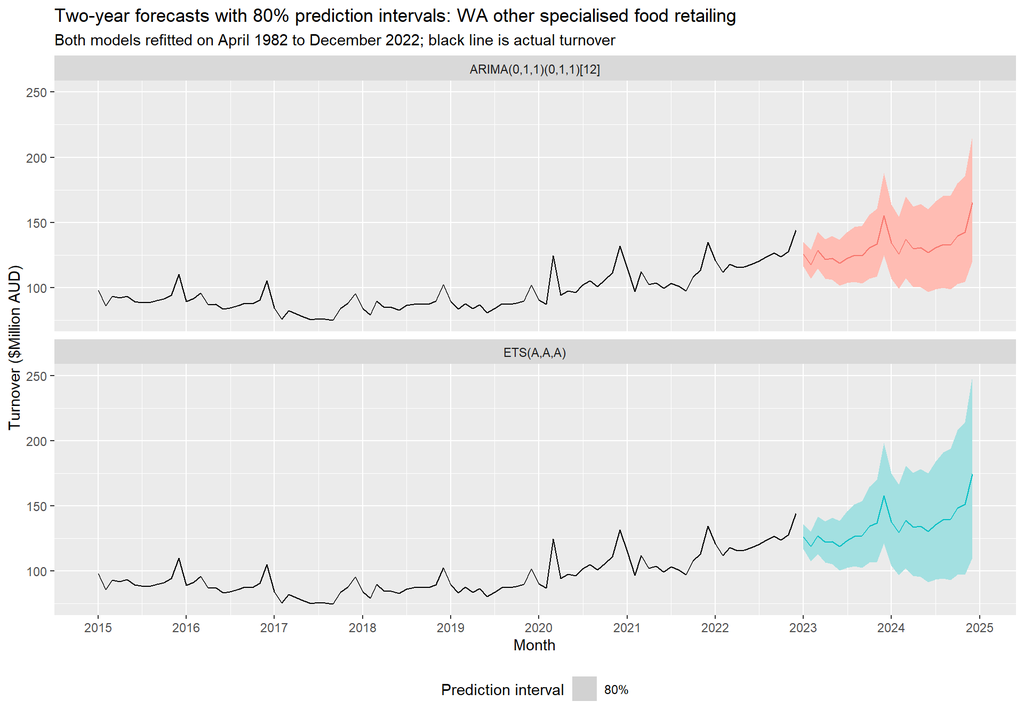

Figure 25

```r
fc_full |>
  mutate(Model = factor(full_labels[.model], levels = full_labels)) |>
  autoplot(retail |> filter(year(Month) >= 2015), level = 80) +
  facet_wrap(vars(Model), ncol = 1) +
  scale_x_yearmonth(date_breaks = "1 year", date_labels = "%Y") +
  guides(colour = "none", fill = "none", fill_ramp = guide_legend(title = "Prediction interval")) +
  theme(legend.position = "bottom") +
  labs(
    title = paste("Two-year forecasts with 80% prediction intervals:", series_name),
    subtitle = "Both models refitted on April 1982 to December 2022; black line is actual turnover",
    x = "Month",
    y = y_lab
  )
```

**Comparing the two forecasts.**

- **2023: almost identical.** Both models forecast average monthly turnover of about $127M-$129M in 2023, up from $122.2M in 2022, with a December 2023 peak of about $155M-$158M. In the first year both forecasts are driven mainly by the latest level and the seasonal pattern, which the two models estimate very similarly.
- **2024: ETS grows faster.** The ETS forecasts average $141M in 2024 against $136M for ARIMA. The refitted ETS model’s growth rate now follows the strong recent growth, while the ARIMA model’s growth is a slowly updated long-run average (its seasonal MA coefficient near -1 means each year’s change has only a small effect on the expected change next year).
- **Uncertainty: the ETS intervals are much wider by the end.** By December 2024 the ETS 80% interval is $140M wide against $96M for ARIMA. The ETS growth rate can now move ($\beta > 0$), so uncertainty about growth compounds with the horizon. Both sets of intervals widen with the horizon and are wider at the December peak, because on the log scale the uncertainty is a percentage of the level.

**Preferred forecast.** On the test-set evidence of Section 8, I prefer the **ETS(A,A,A)** forecast for the point forecasts. However, its 2024 forecasts depend heavily on the higher growth rate learned from 2021-2022, which may not continue if food inflation eases, and its wide intervals reflect that. The ARIMA forecast is a sensible, more conservative alternative. All point forecasts are bias-adjusted means on the $Million AUD scale (Section 11). Section 10 checks how both actually performed.

# 10. Comparing the forecasts with up-to-date ABS data

## The new data

The latest data come from ABS *Retail Trade, Australia*, Table 11 (cat. 8501.0, Retail Turnover, State by Industry Subgroup, Original). The ABS ceased this publication after the **June 2025** release, so that is the most recent version available.

```r
abs_path <- "data/8501011.xlsx"
if (!file.exists(abs_path)) {
  abs_path <- tempfile(fileext = ".xlsx")
  download.file(
    "https://www.abs.gov.au/statistics/industry/retail-and-wholesale-trade/retail-trade-australia/jun-2025/8501011.xlsx",
    abs_path,
    mode = "wb", quiet = TRUE
  )
}

series_id <- unique(retail$`Series ID`)
abs_data <- readxl::read_excel(abs_path, sheet = "Data1", skip = 9) |>
  select(Month = `Series ID`, Turnover = all_of(series_id)) |>
  mutate(
    Month = yearmonth(Month),
    State = unique(retail$State),
    Industry = unique(retail$Industry)
  ) |>
  as_tsibble(index = Month, key = c(State, Industry))

# Check whether the ABS has revised the months we modelled
revision_check <- abs_data |>
  as_tibble() |>
  inner_join(retail |> as_tibble() |> select(Month, Old = Turnover), by = "Month") |>
  summarise(months = n(), max_abs_revision = max(abs(Turnover - Old)))

abs_new <- abs_data |> filter(Month > max(retail$Month))
```

Series A3349508C in the ABS file runs to 2025 Jun, giving 30 new months after the end of our data. The forecasts cover 24 of them (2023 Jan to 2024 Dec), so accuracy is measured on those months; the later months are shown on the plot for context only. The ABS file is identical to the course data in all 489 overlapping months, so no historical revisions affect the comparison.

## How well did the forecasts do?

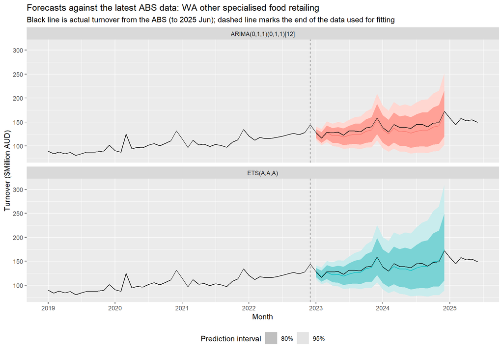

Figure 26

```r
fc_full |>
  mutate(Model = factor(full_labels[.model], levels = full_labels)) |>
  autoplot(abs_data |> filter(year(Month) >= 2019), level = c(80, 95)) +
  geom_vline(xintercept = max(retail$Month), linetype = "dashed", colour = "grey40") +
  facet_wrap(vars(Model), ncol = 1) +
  scale_x_yearmonth(date_breaks = "1 year", date_labels = "%Y") +
  guides(colour = "none", fill = "none", fill_ramp = guide_legend(title = "Prediction interval")) +
  theme(legend.position = "bottom") +
  labs(
    title = paste("Forecasts against the latest ABS data:", series_name),
    subtitle = paste0(
      "Black line is actual turnover from the ABS (to ", format(max(abs_data$Month)),
      "); dashed line marks the end of the data used for fitting"
    ),
    x = "Month",
    y = y_lab
  )
```

```r
abs_acc <- fc_full |>
  accuracy(abs_data) |>
  select(.model, ME, RMSE, MAE, MAPE, MASE)

abs_check <- fc_full |>
  mutate(pi80 = hilo(Turnover, 80), pi95 = hilo(Turnover, 95)) |>
  as_tibble() |>
  inner_join(abs_horizon |> as_tibble() |> select(Month, Actual = Turnover), by = "Month") |>
  group_by(.model) |>
  summarise(
    cover80 = 100 * mean(Actual >= pi80$lower & Actual <= pi80$upper),
    cover95 = 100 * mean(Actual >= pi95$lower & Actual <= pi95$upper),
    fc_2023 = mean(.mean[year(Month) == 2023]),
    fc_2024 = mean(.mean[year(Month) == 2024])
  )

abs_summary <- abs_acc |>
  left_join(abs_check, by = ".model") |>
  mutate(Model = full_labels[.model])

abs_summary |>
  select(Model, ME, RMSE, MAE, MAPE, MASE, cover80, cover95, fc_2023, fc_2024) |>
  knitr::kable(
    digits = 2,
    col.names = c(
      "Model", "Mean error (actual - forecast)", "RMSE", "MAE", "MAPE (%)", "MASE",
      "Actuals inside 80% PI (%)", "Actuals inside 95% PI (%)", "Mean forecast 2023", "Mean forecast 2024"
    ),
    caption = paste0(
      "Forecast accuracy on ", format(min(abs_horizon$Month)), " to ", format(fc_end),
      " ($Million AUD unless stated). Actual mean monthly turnover was $",
      round(mean(abs_horizon$Turnover[year(abs_horizon$Month) == 2023]), 1), "M in 2023 and $",
      round(mean(abs_horizon$Turnover[year(abs_horizon$Month) == 2024]), 1), "M in 2024."
    )
  )
```

Forecast accuracy on 2023 Jan to 2024 Dec ($Million AUD unless stated). Actual mean monthly turnover was $131.8M in 2023 and $143.9M in 2024.

| Model | Mean error (actual - forecast) | RMSE | MAE | MAPE (%) | MASE | Actuals inside 80% PI (%) | Actuals inside 95% PI (%) | Mean forecast 2023 | Mean forecast 2024 |
| --- | --- | --- | --- | --- | --- | --- | --- | --- | --- |
| ARIMA(0,1,1)(0,1,1)[12] | 6.49 | 7.33 | 6.60 | 4.74 | 1.09 | 100 | 100 | 127.07 | 135.66 |
| ETS(A,A,A) | 2.94 | 4.41 | 3.64 | 2.67 | 0.60 | 100 | 100 | 128.61 | 141.22 |

**Both models under-forecast, but ETS(A,A,A) did much better.** Turnover kept growing strongly: average monthly turnover rose from $122.2M in 2022 to $131.8M in 2023 (8%) and $143.9M in 2024 (a further 9%). Both models’ mean errors are positive, meaning both forecasts were too low on average.

- **ETS(A,A,A)** was close: RMSE 4.41 and MAPE 2.67%, and a MASE of 0.6 (well below 1, so its errors were much smaller than the typical error of a seasonal naive forecast). Its 2024 average forecast ($141.2M) was within $2.7M of the actual value. The extra growth it learned from 2021-2022 (the larger $\beta$ in Section 9) is what made the difference: recent growth turned out to be a better guide than the long-run average.
- **ARIMA(0,1,1)(0,1,1)<sub>12</sub>** was further off: RMSE 7.33, MAPE 4.74% and MASE 1.09 (above 1, so its errors were larger than the typical error of a seasonal naive forecast). Its long-run-average growth rate was too slow, so its forecasts fell further below the actual values as the horizon lengthened, reaching $135.7M on average in 2024 against $143.9M. The actual value was above the ARIMA forecast in 23 of the 24 months, so the errors were not random: they show a systematic bias in the growth rate, not bad luck.
- **Prediction intervals.** 100% of the actual values fell inside the ETS 80% intervals and 100% inside the ARIMA 80% intervals. Even the ARIMA forecasts, which were biased, stayed inside their intervals. As in Sections 6 and 7, the intervals were wider than needed, consistent with the heavy-tailed residuals inflating the estimated variance.

**Why did turnover grow faster than the long-run trend?** Several things pushed WA food spending up in 2023-2024. Western Australia had the fastest population growth of any state, driven by record overseas migration and people moving from other states, so there were simply more households buying food. Food price inflation remained high through 2023 before easing in 2024, which raises turnover in current dollars even when volumes do not change. The WA economy was also strong on the back of the resources sector, with low unemployment supporting spending. These are the same forces that drove the 2022 rise, so a model that weighted recent growth more heavily (the refitted ETS) did better than one built around the long-run average (ARIMA). The months after the forecast horizon show growth continuing into 2025.

**Overall**, this confirms the choice in Section 8: the ETS(A,A,A) forecasts were the more accurate. It is worth being honest that part of its success came from a parameter change when the model was refitted, which happened to suit the next two years; had food inflation and population growth slowed sharply, the more conservative ARIMA forecasts could have done better.

# 11. Benefits and limitations of the two models

**Interpretability.** ETS(A,A,A) is easier to explain, because its parts are a level, a growth rate of about 5.2% a year and a December peak about 20% above the level (training fit). ARIMA’s coefficients only make sense once translated into how much of each surprise is kept.

**Changing seasonality.** Both models let the December peak evolve, which this series needs. However, after refitting on all the data, ETS’s $\gamma$ fell to almost zero, so its 2023-2024 forecasts hold the seasonal pattern fixed at its 2022 shape.

**Sensitivity to recent data.** Both models over-forecast 2021 because training ended just after the COVID-19 jump. When refitted, the ETS growth parameter $\beta$ rose from 0.00015 to 0.028. That happened to suit 2023-2024, but it shows ETS can be swayed by a few unusual years, while ARIMA was stable but slower to pick up faster growth.

**Assuming the past continues.** Both models use only past turnover, so they cannot foresee shocks like Y2K, the GST or COVID-19, or use the drivers behind 2023-2024 such as WA population growth and food prices. Because turnover is in current dollars, a change in inflation would push both forecasts wrong in the same direction.

**Residuals and intervals.** The ARIMA residuals are white noise (p = 0.31) while the ETS residuals are borderline (p = 0.06), so ARIMA uses short-term information better even though ETS forecast more accurately. Both have long-tailed residuals, so their intervals were too wide in ordinary months: every test-set month and every 2023-2024 month fell inside the 80% intervals, when only about 80% would be expected.

**Back-transformation bias.** Reversing the log gives the median forecast, which sits below the mean because the dollar-scale distribution is skewed. `fable` reports the bias-adjusted mean instead, and the adjustment grows with the horizon, reaching 2.6% (ARIMA) and 5.1% (ETS) after two years.

**Overall.** ETS(A,A,A) gave the more accurate and more easily explained forecasts, but it depends more on its latest estimates. ARIMA is more stable and has cleaner residuals, but it under-forecast the strong recent growth.